# learning_objectives

muhammad khizer khan

12/3/2021

With library() we can import packages that we want to use in our system.

```r
library(ggmap)
library(tidyverse)
```

With the read.csv() function, We can read csv files in our program As I have files with name IndiaWantsOxygen.csv and worldcities.csv that are saved on different locations (C:/Users/khizer/Documents/GVSU courses/3rd semester/STA518/project/data sets , C:/Users/khizer/Documents/GVSU courses/3rd semester/STA518/project/data sets) so with the help of following code I read csv files

```r
data = read.csv("C:/Users/khizer/Documents/GVSU courses/3rd semester/STA518/project/data sets/IndiaWantsOxygen.csv")
countries = read.csv("C:/Users/khizer/Documents/GVSU courses/3rd semester/STA518/project/data sets/worldcities.csv")
```

##Clean data

We clean data on the basis of our need. For example I want to know the name of the country and city of the user in my data set. We have a column with the name userlocation in which we have one of the following values. 1) city or country 2) city and country 3) garbage value 4) missing values.

```r
data = as.tibble(data)
data[1:2,]
```

```
## # A tibble: 2 x 13
##   user_name   user_location  user_description        user_created user_followers
##   <chr>       <chr>          <chr>                   <chr>                 <int>
## 1 Localwaala  ""             The one stop portal fo~ 2021-05-17 ~              2
## 2 Ka'ab Rana~ "Faisalabad, ~ I'm a student of biolo~ 2017-06-17 ~             40
## # ... with 8 more variables: user_friends <int>, user_favourites <int>,
## #   user_verified <chr>, date <chr>, text <chr>, hashtags <chr>, source <chr>,
## #   is_retweet <chr>
```

We have some values of countries in country data set that are not in our data set for example we have 1) United states not USA 2) United Kingdom not England etc so we need to add these values too

```r
countries[nrow(countries) + 1, 5] = "England"
countries[nrow(countries) + 1, 5] = "INDIA"
countries[nrow(countries) + 1, 5] = "india"
countries[nrow(countries) + 1, 5] = "USA"
countries[nrow(countries) + 1, 5] = "england"
country_list = unique(countries$country)
```

First I will remove all the data in which we have missing values in userlocation

```r
data_without_empty_values = filter(data, user_location != '')
```

As we have following condition of tidy data 1)Every cell is a value 2)Every row is an observation 3)Every column is a variable

As you can see our data is untidy as it met all the conditions except the last one.Userlocation contains both city and country so to make it untidy I have to split this column in to two city and country

```r
data_without_empty_values <- data_without_empty_values %>% separate(user_location, c('City', 'Country'))
```

We have one data set of country. There are some garbage values in country column so we will compare the values of country data set and country column. If we have any value in country column which is not in country data set it means it is garbage value so we will remove it and set NA

```r
data_without_empty_values <- data_without_empty_values %>%
       mutate(Country = ifelse(match(Country, country_list) > 0, Country, NA))
data_without_empty_values[1:2,]
```

```
## # A tibble: 2 x 14
##   user_name   City   Country  user_description       user_created user_followers
##   <chr>       <chr>  <chr>    <chr>                  <chr>                 <int>
## 1 Ka'ab Rana~ Faisa~ Pakistan "I'm a student of bio~ 2017-06-17 ~             40
## 2 Muhammad I~ USA    <NA>     "Visit Muhammad Qasim~ 2020-11-27 ~            309
## # ... with 8 more variables: user_friends <int>, user_favourites <int>,
## #   user_verified <chr>, date <chr>, text <chr>, hashtags <chr>, source <chr>,
## #   is_retweet <chr>
```

Now we have city data set and we will compare the value of city column to city dataset. If the value is match and country column is NA so we will set the name of the country on the basis of city other wise we will keep the previous name of the country column

```r
data_without_empty_values <- data_without_empty_values %>%
  mutate(Country = ifelse(match(City, countries$city) > 0 & is.na(Country) , countries$country[match(City, countries$city)], Country))
data_without_empty_values[1:2,]
```

```
## # A tibble: 2 x 14
##   user_name   City   Country  user_description       user_created user_followers
##   <chr>       <chr>  <chr>    <chr>                  <chr>                 <int>
## 1 Ka'ab Rana~ Faisa~ Pakistan "I'm a student of bio~ 2017-06-17 ~             40
## 2 Muhammad I~ USA    <NA>     "Visit Muhammad Qasim~ 2020-11-27 ~            309
## # ... with 8 more variables: user_friends <int>, user_favourites <int>,
## #   user_verified <chr>, date <chr>, text <chr>, hashtags <chr>, source <chr>,
## #   is_retweet <chr>
```

We also have some country names in city column so we well compare city values with country names and if we have any so we will save that name in to country

```r
data_without_empty_values <- data_without_empty_values %>%
  mutate(Country = ifelse(match(City, country_list) > 0 & is.na(Country) , countries$country[match(City, countries$country)], Country))
data_without_empty_values[1:2,]
```

```
## # A tibble: 2 x 14
##   user_name   City   Country  user_description       user_created user_followers
##   <chr>       <chr>  <chr>    <chr>                  <chr>                 <int>
## 1 Ka'ab Rana~ Faisa~ Pakistan "I'm a student of bio~ 2017-06-17 ~             40
## 2 Muhammad I~ USA    USA      "Visit Muhammad Qasim~ 2020-11-27 ~            309
## # ... with 8 more variables: user_friends <int>, user_favourites <int>,
## #   user_verified <chr>, date <chr>, text <chr>, hashtags <chr>, source <chr>,
## #   is_retweet <chr>
```

```r
data_without_na_values <- data_without_empty_values %>%
    select(Country)%>%
    filter(!is.na(Country))%>%
  mutate(country_count = 1)


data_without_na_values = data_without_na_values %>%
 mutate(country_count = ifelse(Country == "USA", country_count * 3, ifelse(Country == "United Arab Emirates", country_count * 3,ifelse(Country == "Australia", country_count * 8,ifelse(Country == "New Zealand", country_count * 15, ifelse(Country == "Canada", country_count * 10, ifelse(Country == "Germany", country_count * 63, country_count)))))))

data_without_na_values <- data_without_na_values %>%
    group_by(Country) %>%
    dplyr::summarise(country_count = sum(country_count)) %>%
    as.data.frame()
```

Now we have clean our data and this is the time of making a heat map of world to show on which part of the world people are more talking about indianeedsoxygen

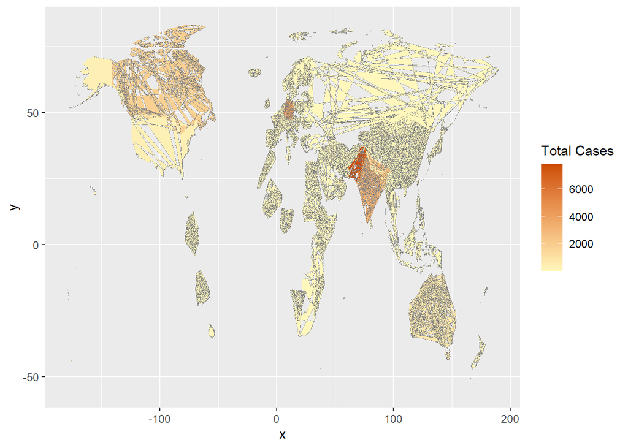

```r
world_map = map_data("world")
 world_map = merge(world_map, data_without_na_values, by.x = "region", by.y = "Country")

# ggplot(world_map, aes(x = long, y = lat, group = group, fill = count_country), fill = "white", color = "#7f7f7f", #size = 0.25)+
 #     geom_polygon()


ggplot(data_without_na_values) +
  geom_map(
    dat = world_map, map = world_map, aes(map_id = region),
    fill = "white", color = "#7f7f7f", size = 0.25
  ) +
  geom_map(map = world_map, aes(map_id = Country, fill = country_count), size = 0.25) +
  scale_fill_gradient(low = "#fff7bc", high = "#cc4c02", name = "Total Cases") +
  expand_limits(x = world_map$long, y = world_map$lat)
```

Now we are reading one more data for summaries and graphical analysis

```r
testing_details = read.csv("C:/Users/khizer/Documents/GVSU courses/3rd semester/STA518/project/data sets/StatewiseTestingDetails.csv")
testing_details = as.tibble(testing_details)
testing_details[1:2,]
```

```
## # A tibble: 2 x 5
##   Date       State                       TotalSamples Negative Positive
##   <chr>      <chr>                              <dbl>    <int>    <dbl>
## 1 2020-04-17 Andaman and Nicobar Islands         1403     1210       12
## 2 2020-04-24 Andaman and Nicobar Islands         2679       NA       27
```

In this above data set some values have NA in negative cases variable, some values have NA in positive cases and some values have NA in both positive and negative cases so we will do the following steps to transform data in our format. 1) Remove all the records in which negative and positive both have NA values 2) if negative is NA so subtract totalSamples with positive cases the answer will be negative cases a)Negative = TotalSamples - Positive 3) if Positive is NA so subtract totalSamples with negative cases the answer will be positive cases a)Positive = TotalSamples - Negative 4) add new variable “Percentage_of_positive_cases”

Now the positive and negative cases are not as explanatory as percentage. With the percentage the help of percentage we have a better idea of number of covid patients in that state

```r
testing_details = testing_details %>%
    filter(!is.na(Negative) | !is.na(Positive)) %>%
    mutate(Negative = ifelse(is.na(Negative), TotalSamples - Positive, Negative),
           Positive = ifelse(is.na(Positive), TotalSamples - Negative, Positive),
           percentage_of_positive_cases = (Positive/TotalSamples) * 100)

testing_details[1:4,]
```

```
## # A tibble: 4 x 6
##   Date       State           TotalSamples Negative Positive percentage_of_posit~
##   <chr>      <chr>                  <dbl>    <dbl>    <dbl>                <dbl>
## 1 2020-04-17 Andaman and Ni~         1403     1210       12                0.855
## 2 2020-04-24 Andaman and Ni~         2679     2652       27                1.01
## 3 2020-04-27 Andaman and Ni~         2848     2815       33                1.16
## 4 2020-05-01 Andaman and Ni~         3754     3721       33                0.879
```

Now make some visualizations for better understanding of numbers

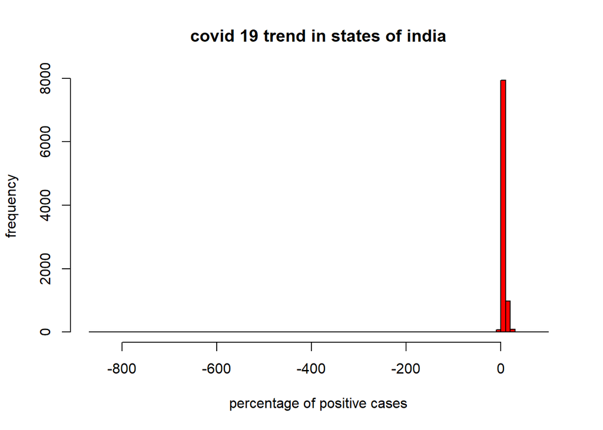

```r
hist(testing_details$percentage_of_positive_cases,breaks = 100, col = "red", main = "covid 19 trend in states of india", xlab =  "percentage of positive cases",  ylab = "frequency")
```

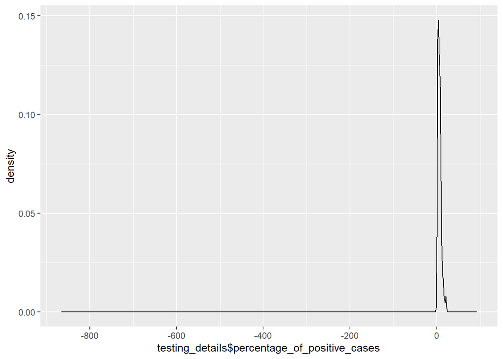

```r
ggplot(testing_details, aes(testing_details$percentage_of_positive_cases)) +
    geom_density()
```